# PROJECT 1. EXPLORE WEATHER TRENDS

## Step 1: Extract the data from the database

First, using SQL the name of the cities in my country, Spain, was searched. Barcelona was chosen as the nearest city to my hometown.

[figure not shown]

Then the weather data from Barcelona was downloaded as a CSV also using SQL.

[figure not shown]

Finally, the global weather data was downloaded as a CSV.

[figure not shown]

## Step 2: Open up the CSV

The CSV was open using Excel. Then text was converted into columns to be able to operate with them. In the data from Barcelona - Spain, there was found also the data from Barcelona - Venezuela and it was deleted. Furthermore, the data of the two CSV was merged into one XLSX.

[figure not shown]

## Step 3: Create a line chart

To represent the temeprature data of the world and Barcelona a moving average of 7 years was done. Then the data was imported and opened to check that everything was correct.

```python
from pandas import DataFrame, read_csv
import matplotlib.pyplot as plt

file = r'data.xlsx'
df = pd.read_excel(file)
print(df)
```

```
       year       city country  bcn_avg_temp  Bcn_avg_7yr  g_avg_temp  \
0    1743.0  Barcelona   Spain         13.81          NaN         NaN
1    1744.0  Barcelona   Spain         16.98          NaN         NaN
2    1745.0  Barcelona   Spain         10.78          NaN         NaN
3    1746.0  Barcelona   Spain           NaN          NaN         NaN
4    1747.0  Barcelona   Spain           NaN          NaN         NaN
5    1748.0  Barcelona   Spain           NaN          NaN         NaN
6    1749.0  Barcelona   Spain           NaN          NaN         NaN
7    1750.0  Barcelona   Spain         16.52          NaN        8.72
8    1751.0  Barcelona   Spain         16.78          NaN        7.98
9    1752.0  Barcelona   Spain         13.09          NaN        5.78
10   1753.0  Barcelona   Spain         16.17          NaN        8.39
11   1754.0  Barcelona   Spain         16.09          NaN        8.47
12   1755.0  Barcelona   Spain         15.80          NaN        8.36
13   1756.0  Barcelona   Spain         16.11    15.794286        8.85
```

[output cut: 112 more lines]

Then the line chart was created.

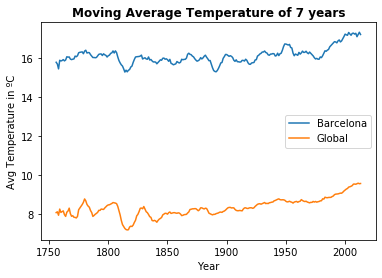

```python
plt.plot(df.year, df.Bcn_avg_7yr, label="Barcelona")
plt.plot(df.year, df.Global_avg_yr, label="Global")

plt.xlabel("Year")
plt.ylabel("Avg Temperature in ºC")
plt.title("Moving Average Temperature of 7 years", weight="bold")
plt.legend()
plt.show()
```

Then, just for curiosity, the line chart of the same data without the moving average was plotted.

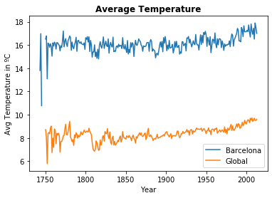

```python
plt.plot(df.year, df.bcn_avg_temp, label="Barcelona")
plt.plot(df.year, df.g_avg_temp, label="Global")

plt.xlabel("Year")
plt.ylabel("Avg Temperature in ºC")
plt.title("Average Temperature", weight="bold")
plt.legend()
plt.show()
```

## Step 4: Observe the chart line

Some conclusions about the chart line:

- Barcelona is a hotter city than the global average, as the temperature is almost the double.
- The temperature since 1975 has increased in Barcelona and in the world.
- Since 1850 the global temperature has benn increasing quite constantly, while in Spain it has fluctuated.
- Before 1850 the temperature fluctuated more in Barcelona and in the world.